# Prevalence of Alcohol Use Characterized by Phosphatidylethanol in Patients with Respiratory Failure Before and During the COVID-19 Pandemic

Author

Ellen Burnham et al.

# Statistical Analysis: Figures and tables

## Table 1

Table 1: Study demographics and in-patient outcomes, stratified by pandemic era

| **Clinical Characteristics** | **Pre-pandemic**, N = 141 | **Peri-pandemic**, N = 92 | **p-value** |
| --- | --- | --- | --- |
| Age, mean (SD) | 54.5 (13.9) | 55.2 (15.0) | 0.8 |
| Male sex | 80 (57%) | 70 (76%) | 0.003 |
| Hispanic ethnicity | 32 (23%) | 47 (51%) | <0.001 |
| Race (self-reported) |  |  | 0.8 |
| African American | 20 (14%) | 8 (8.7%) |  |
| American Indian | 1 (0.7%) | 1 (1.1%) |  |
| Asian | 3 (2.1%) | 1 (1.1%) |  |
| More than one race | 2 (1.4%) | 0 (0%) |  |
| Pacific Islander | 2 (1.4%) | 2 (2.2%) |  |
| Unknown / Refused to answer | 1 (0.7%) | 1 (1.1%) |  |
| White | 112 (79%) | 79 (86%) |  |
| Non-white race | 28 (20%) | 12 (13%) | 0.2 |
| Smoking history |  |  | 0.001 |
| Current smoker | 54 (39%) | 18 (20%) |  |
| Never or former smoker | 83 (61%) | 74 (80%) |  |
| APACHE II score at admission, mean (SD) | 20.1 (7.0) | 17.9 (6.8) | 0.022 |
| History of Diabetes | 36 (26%) | 20 (22%) | 0.5 |
| History of Cirrhosis | 19 (13%) | 6 (6.5%) | 0.13 |
| Body Mass Index [kg/m2], mean (SD) | 29.5 (9.6) | 32.6 (10.2) | 0.012 |
| Days of mechanical ventilation, median (IQR) | 5 (3, 10) | 8 (4, 15) | <0.001 |
| Days in ICU, median (IQR) | 9 (5, 13) | 11 (7, 19) | 0.007 |
| Days in hospital, median (IQR) | 14 (9, 24) | 17 (11, 26) | 0.044 |
| Discharged to home | 49 (35%) | 47 (51%) | 0.015 |
| In-hospital mortality | 40 (28%) | 22 (24%) | 0.5 |

**Note: those with unknown race not counted as “Non-white”.**

## Table 2

Table 2: Alcohol use in the cohort.

| **Patient Alcohol Use Metrics and Characteristics** | **Pre-pandemic**, N = 141 | **Peri-pandemic**, N = 92 | **p-value** |
| --- | --- | --- | --- |
| AUDIT-C score, median (IQR) | 0 (0, 3) | 0 (0, 1) | 0.2 |
| PEth [ng/mL], median (IQR) | 0 (0, 79) | 186 (69, 398) | <0.001 |
| Likely alcohol misuse, AUDIT-C definition | 20 (26%) | 11 (14%) | 0.072 |
| Alcohol Misuse, PEth cut-point from AFSHAR ET AL. |  |  | <0.001 |
| High | 38 (38%) | 82 (90%) |  |
| Low | 63 (62%) | 9 (9.9%) |  |
| Current alcohol drinking, composite definition | 81 (60%) | 85 (93%) | <0.001 |
| Alcohol consumption, PEth definition |  |  | <0.001 |
| Light or no alcohol consumption (PEth <20 ng/mL) | 63 (62%) | 8 (8.8%) |  |
| Significant alcohol consumption (PEth 20-199 ng/mL) | 19 (19%) | 40 (44%) |  |
| Heavy alcohol consumption (PEth ≥ 200) | 19 (19%) | 43 (47%) |  |
| AUDIT-C = Zero | 47 (60%) | 55 (69%) | 0.3 |

> AUDIT-C = alcohol use disorders identification test-C; PEth = phosphatidylethanol.

## Table 3

> Effects of alcohol misuse, defined by PEth, on selected ICU and hospital outcomes, in unadjusted analyses and after adjustment for covariates.

**Unadjusted (MI)**

| Outcome | odds ratio | 95% CI lwr | 95% CI upr | p-value |
| --- | --- | --- | --- | --- |
| Mechanical ventilation days | 1.26 | 0.73 | 2.17 | 0.39 |
| Intensive care unit days | 1.19 | 0.72 | 1.97 | 0.49 |
| Hospital days | 1.07 | 0.66 | 1.76 | 0.78 |
| Mortality | 0.95 | 0.49 | 1.86 | 0.88 |
| Discharge to home | 1.79 | 0.99 | 3.22 | 0.054 |

**Adjusted (MI)**

| Outcome | odds ratio | 95% CI lwr | 95% CI upr | p-value |
| --- | --- | --- | --- | --- |
| Mechanical ventilation days | 0.81 | 0.39 | 1.69 | 0.56 |
| Intensive care unit days | 1.04 | 0.56 | 1.93 | 0.90 |
| Hospital days | 0.87 | 0.47 | 1.60 | 0.65 |
| Mortality | 1.63 | 0.67 | 3.98 | 0.28 |
| Discharge to home | 1.14 | 0.52 | 2.51 | 0.74 |

**Unadjusted (CC)**

|  | coef | std.err | z.stat | p.value |
| --- | --- | --- | --- | --- |
| MV Days | 0.28 | 0.26 | 1.06 | 0.29 |
| ICU Days | 0.30 | 0.26 | 1.15 | 0.25 |
| Hospital Days | 0.13 | 0.26 | 0.49 | 0.63 |
| Mortality | -0.19 | 0.34 | -0.56 | 0.58 |
| Discharge to home | 0.50 | 0.31 | 1.65 | 0.100 |

**Adjusted (CC)**

|  | coef | std.err | z.stat | p.value |
| --- | --- | --- | --- | --- |
| MV Days | -0.27 | 0.36 | -0.76 | 0.45 |
| ICU Days | 0.16 | 0.35 | 0.46 | 0.64 |
| Hospital Days | 0.02 | 0.35 | 0.05 | 0.96 |
| Mortality | 0.28 | 0.50 | 0.55 | 0.58 |
| Discharge to home | 0.35 | 0.47 | 0.74 | 0.46 |

**Note: complete case (CC) for internal use only.**

## Figure 1

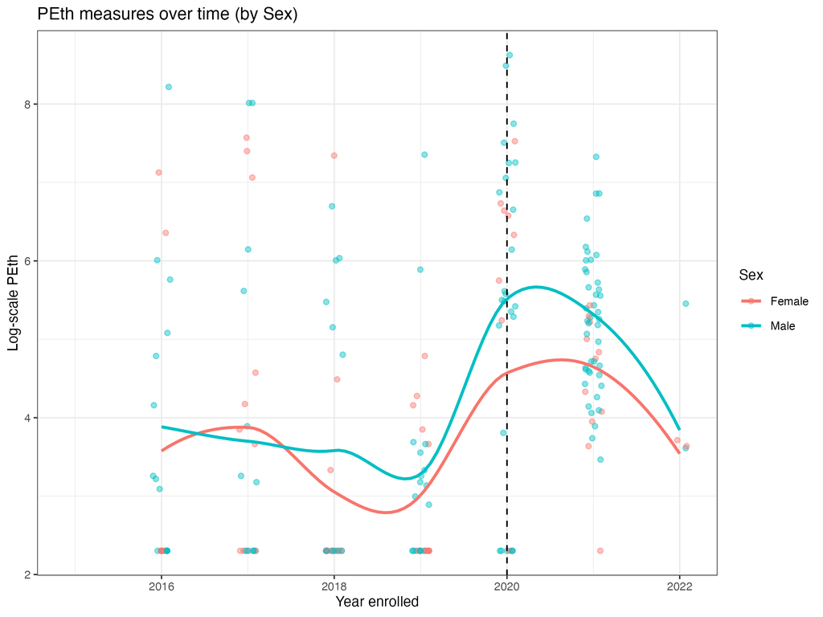

Figure 1: Phosphatidylethanol (PEth) measures among critically ill patients over time. Data from 192 total patients with available PEth values, stratified by sex. Dashed line represents approximate start of the pandemic.

## Figure 2

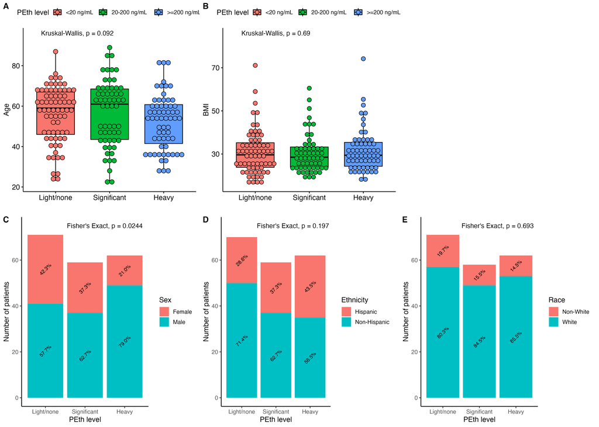

Figure 2: Relationship between PEth and demographic covariates of interest

## Figure 3

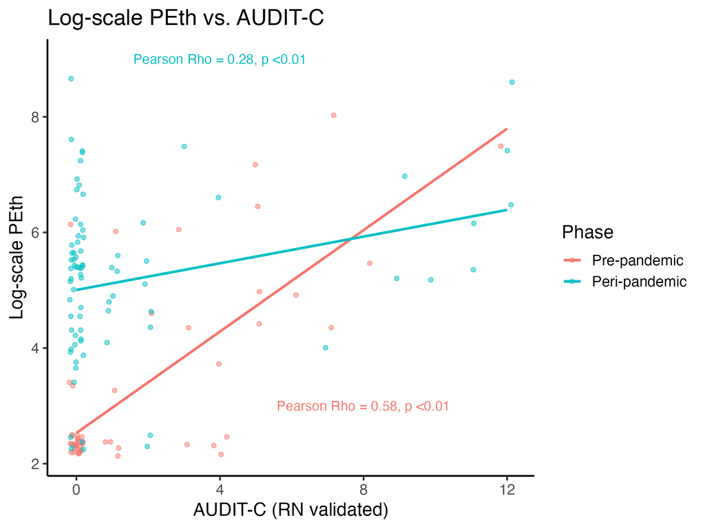

Figure 3: Relationship between PEth and AUDIT-C. Data from 133 patients with AUDIT-C and PEth (correlations and p-values obtained after multiple imputation).

We evaluated the association between PEth (log-scale) and AUDIT-C, stratified by pandemic phase, using multiply-imputed datasets and Pearson correlation.

**Using multiple imputation (MI)**

Using multiply-imputed data from the entire cohort, log-transformed PEth measures were correlated with AUDIT-C scores berfore the pandemic (Pearson’s rho=**0.58**, p<0.01), and during the pandemic (Pearson’s rho=**0.28**, p=0.009). Correlations were significantly different between pandemic eras (p-value: **0.0011**).

**Complete-case (CC) analysis**

Using complete cases from the entire cohort, log-transformed PEth measures were correlated with AUDIT-C scores berfore the pandemic (Pearson’s rho=**0.72**, p<0.01), and during the pandemic (Pearson’s rho=**0.27**, p=0.016). Correlations were significantly different between pandemic eras (p-value: **< 0.001**).

**Note: complete case (CC) for internal use only.**

## New Analysis: Sensitivity/Specificity of AUDIT-C

We treated binarized PEth values (≥25 ng/mL) as the gold-standard predictor of alcohol misuse. We then compared the sensitivity, specificity, and predictive value of AUDIT-C as a diagnostic screener for alcohol misuse, both before and during the pandemic. The cut-point for AUDIT-C was ≥4 for males and ≥3 for females.

Since datasets were multiply imputed, we aggregated results by assuming each operating characteristic (e.g. sensitivity) was normally distributed with standard error:

$$SE(\hat{p})=\sqrt{\frac{\hat{p}(1-\hat{p})}{n}}$$
where $\hat{p}$ was the estimated value of the operating characteristic on a single imputed dataset. Using Rubin’s rule (1987) for mutliply imputed data, we summarized the point estimate for each operating characteristic, as well as the 95% confidence interval.

| Metric | Prepandemic | 95% Conf. Int | Peripandemic | 95% Conf. Int |
| --- | --- | --- | --- | --- |
| Sensitivity | 0.458 | (0.32, 0.59) | 0.172 | (0.08, 0.26) |
| Specificity | 0.910 | (0.85, 0.97) | 0.982 | (0.89, 1.07) |
| PPV | 0.803 | (0.71, 0.89) | 0.987 | (0.92, 1.05) |
| NPV | 0.679 | (0.6, 0.76) | 0.127 | (0.06, 0.2) |

During the pandemic, both the specificity and PPV of AUDIT-C improved, though the confidence intervals for wpecificity were overlapping across pandemic eras. The improvement in PPV was driven, at least in part, by greater prevalence of high PEth during the pandemic.

Sensitivity of AUDIT-C declined from 0.458 to 0.172. Thus, AUDIT-C was less likely to identify alcohol users (i.e., those who had high PEth), during the pandemic.

Similarly, negative predicted value (NPV) declined from 0.679 to 0.127 during the pandemic, meaning a large proportion of those with low AUDIT-C also had high PEth and went undetected.

# Supplemental Analyses

## Supplemental Figure 1

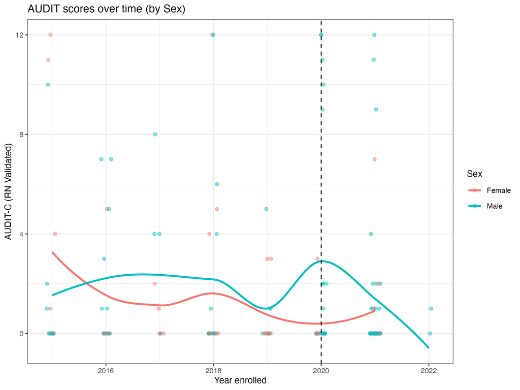

Supplemental Figure 1. AUDIT-C scores among critically ill patients over time. Data from 158 total patients, stratified by sex. Dashed line represents approximate start of the pandemic.

## Supplemental Table 1

> Relationship between PEth and covariates of interest.

| effect | odds ratio | 95% CI lwr | 95% CI upr | p-value |
| --- | --- | --- | --- | --- |
| Age | 0.99 | 0.97 | 1.02 | 0.52 |
| Sex: Male | 1.51 | 0.88 | 2.59 | 0.13 |
| Race: Non-white | 1.04 | 0.49 | 2.19 | 0.91 |
| Hispanic | 0.72 | 0.39 | 1.35 | 0.30 |
| APACHE II | 1.01 | 0.96 | 1.05 | 0.79 |
| Diabetes + | 0.35 | 0.18 | 0.67 | 0.002 |
| Cirrhosis + | 0.47 | 0.17 | 1.31 | 0.14 |
| Current smoker | 1.75 | 0.89 | 3.44 | 0.10 |
| COVID + | 2.73 | 1.09 | 6.86 | 0.033 |
| Pre-pandemic | 0.42 | 0.19 | 0.91 | 0.029 |

> Estimates from a model with PEth treated as a continuous outcome, using ordinal regression to handle the non-normality in the distribution of PEth. Results obtained from 5 multiply-imputed data sets. APACHE = Acute Physiology and Chronic Health Evaluation.

## Supplemental Table 2

> Sensitivity analysis to determine effects of alcohol misuse, defined by PEth (trichotomized values), on selected ICU and hospital outcomes, in unadjusted analyses and after adjustment for covariates

**Unadjusted**

| Outcome | effect | odds ratio | 95% CI lwr | 95% CI upr | p-value |
| --- | --- | --- | --- | --- | --- |
| Mechanical ventilation days | PEth level: Significant | 1.20 | 0.58 | 2.46 | 0.61 |
| Mechanical ventilation days | PEth level: Heavy | 1.46 | 0.83 | 2.57 | 0.19 |
| Intensive care unit days | PEth level: Significant | 1.17 | 0.65 | 2.14 | 0.59 |
| Intensive care unit days | PEth level: Heavy | 1.32 | 0.75 | 2.34 | 0.33 |
| Hospital days | PEth level: Significant | 0.99 | 0.55 | 1.80 | 0.98 |
| Hospital days | PEth level: Heavy | 1.30 | 0.72 | 2.33 | 0.38 |
| Mortality | PEth level: Significant | 1.16 | 0.55 | 2.43 | 0.70 |
| Mortality | PEth level: Heavy | 0.74 | 0.32 | 1.69 | 0.46 |
| Discharge to home | PEth level: Significant | 1.37 | 0.67 | 2.77 | 0.38 |
| Discharge to home | PEth level: Heavy | 2.52 | 1.30 | 4.91 | 0.007 |

**Adjusted**

| Outcome | effect | odds ratio | 95% CI lwr | 95% CI upr | p-value |
| --- | --- | --- | --- | --- | --- |
| Mechanical ventilation days | PEth level: Significant | 0.86 | 0.37 | 2.01 | 0.71 |
| Mechanical ventilation days | PEth level: Heavy | 0.86 | 0.39 | 1.88 | 0.69 |
| Intensive care unit days | PEth level: Significant | 1.05 | 0.53 | 2.08 | 0.88 |
| Intensive care unit days | PEth level: Heavy | 1.14 | 0.56 | 2.33 | 0.71 |
| Hospital days | PEth level: Significant | 0.83 | 0.42 | 1.65 | 0.59 |
| Hospital days | PEth level: Heavy | 1.06 | 0.53 | 2.12 | 0.88 |
| Mortality | PEth level: Significant | 1.96 | 0.75 | 5.08 | 0.17 |
| Mortality | PEth level: Heavy | 1.24 | 0.42 | 3.71 | 0.69 |
| Discharge to home | PEth level: Significant | 0.95 | 0.39 | 2.34 | 0.92 |
| Discharge to home | PEth level: Heavy | 1.55 | 0.65 | 3.75 | 0.32 |

## Supplemental Table 3

> Sensitivity analysis to determine effects of alcohol misuse, defined by AUDIT-C scores, on selected ICU and hospital outcomes, in unadjusted analyses and after adjustment for covariates.

**Unadjusted**

| Outcome | odds ratio | 95% CI lwr | 95% CI upr | p-value |
| --- | --- | --- | --- | --- |
| Mechanical ventilation days | 0.52 | 0.26 | 1.07 | 0.073 |
| Intensive care unit days | 0.68 | 0.39 | 1.18 | 0.17 |
| Hospital days | 0.92 | 0.48 | 1.75 | 0.79 |
| Mortality | 0.41 | 0.12 | 1.37 | 0.14 |
| Discharge to home | 2.34 | 1.06 | 5.17 | 0.035 |

**Adjusted**

| Outcome | odds ratio | 95% CI lwr | 95% CI upr | p-value |
| --- | --- | --- | --- | --- |
| Mechanical ventilation days | 0.82 | 0.36 | 1.90 | 0.63 |
| Intensive care unit days | 1.12 | 0.61 | 2.06 | 0.71 |
| Hospital days | 1.43 | 0.72 | 2.85 | 0.31 |
| Mortality | 0.37 | 0.08 | 1.68 | 0.18 |
| Discharge to home | 2.44 | 0.84 | 7.11 | 0.097 |

> The above estimates are the effects of alcohol misuse defined by AUDIT-C ≥4 (yes versus no). Adjusted effects were estimated from models with covariates including: age, sex, race, ethnicity, APACHE II, diabetes, cirrhosis, current smoking, and COVID status. OR is the odds ratio (with 95% confidence interval) of having higher values of the outcome (e.g., the odds ratio of staying on a ventilator for a greater number of days). PEth results were pooled from five multiply imputed datasets to categorize patients as alcohol misuse versus no alcohol misuse at the 25 ng/mL threshold.

**Note: AUDIT-C threshold was ≥4 for males, ≥3 for females.**

## Supplemental Table 4

> Relationship between Alcohol Misuse and Days on Mechanical Ventilation

| effect | odds ratio | 95% CI lwr | 95% CI upr | p-value |
| --- | --- | --- | --- | --- |
| Age | 0.99 | 0.97 | 1.00 | 0.13 |
| Sex: Male | 1.78 | 1.09 | 2.91 | 0.021 |
| Race: Non-white | 1.20 | 0.64 | 2.24 | 0.57 |
| Hispanic | 1.69 | 0.95 | 3.03 | 0.076 |
| APACHE II | 1.03 | 0.99 | 1.07 | 0.17 |
| Diabetes + | 1.18 | 0.66 | 2.11 | 0.57 |
| Cirrhosis + | 2.35 | 1.06 | 5.20 | 0.035 |
| Current smoker | 0.50 | 0.28 | 0.88 | 0.017 |
| COVID + | 3.94 | 1.46 | 10.67 | 0.007 |
| Pre-pandemic | 1.25 | 0.57 | 2.74 | 0.57 |
| PEth level: High | 0.81 | 0.39 | 1.69 | 0.56 |

> PEth results used to define alcohol misuse by PEth obtained from 5 multiply-imputed data sets. APACHE = Acute Physiology and Chronic Health Evaluation.

## Supplemental Table 5

> Relationship between Alcohol Misuse and Days in ICU

| effect | odds ratio | 95% CI lwr | 95% CI upr | p-value |
| --- | --- | --- | --- | --- |
| Age | 1.00 | 0.98 | 1.02 | 0.87 |
| Sex: Male | 1.40 | 0.86 | 2.27 | 0.17 |
| Race: Non-white | 1.23 | 0.65 | 2.32 | 0.52 |
| Hispanic | 1.78 | 1.03 | 3.07 | 0.040 |
| APACHE II | 1.00 | 0.96 | 1.03 | 0.83 |
| Diabetes + | 1.40 | 0.79 | 2.47 | 0.25 |
| Cirrhosis + | 1.69 | 0.78 | 3.62 | 0.18 |
| Current smoker | 0.42 | 0.24 | 0.73 | 0.002 |
| COVID + | 1.75 | 0.67 | 4.56 | 0.25 |
| Pre-pandemic | 1.14 | 0.52 | 2.49 | 0.74 |
| PEth level: High | 1.04 | 0.56 | 1.93 | 0.90 |

> PEth results used to define alcohol misuse by PEth obtained from 5 multiply-imputed data sets. APACHE = Acute Physiology and Chronic Health Evaluation.

## Supplemental Table 6

> Relationship between Alcohol Misuse and In-hospital Mortality

| effect | odds ratio | 95% CI lwr | 95% CI upr | p-value |
| --- | --- | --- | --- | --- |
| Age | 1.03 | 1.01 | 1.06 | 0.012 |
| Sex: Male | 2.19 | 1.00 | 4.76 | 0.049 |
| Race: Non-white | 0.98 | 0.36 | 2.64 | 0.97 |
| Hispanic | 2.33 | 1.05 | 5.18 | 0.037 |
| APACHE II | 1.08 | 1.03 | 1.14 | 0.003 |
| Diabetes + | 0.94 | 0.42 | 2.11 | 0.87 |
| Cirrhosis + | 10.99 | 3.68 | 32.83 | < 0.001 |
| Current smoker | 0.77 | 0.34 | 1.75 | 0.52 |
| COVID + | 0.92 | 0.24 | 3.54 | 0.91 |
| Pre-pandemic | 1.74 | 0.55 | 5.47 | 0.35 |
| PEth level: High | 1.63 | 0.67 | 3.98 | 0.28 |

> PEth results used to define alcohol misuse by PEth obtained from 5 multiply-imputed data sets. APACHE = Acute Physiology and Chronic Health Evaluation.

## Supplemental Table 7

> Relationship between Alcohol Misuse and Discharge Home (yes or no)

| effect | odds ratio | 95% CI lwr | 95% CI upr | p-value |
| --- | --- | --- | --- | --- |
| Age | 0.96 | 0.94 | 0.98 | < 0.001 |
| Sex: Male | 0.63 | 0.32 | 1.21 | 0.16 |
| Race: Non-white | 0.73 | 0.31 | 1.74 | 0.48 |
| Hispanic | 1.12 | 0.54 | 2.32 | 0.76 |
| APACHE II | 0.92 | 0.87 | 0.96 | < 0.001 |
| Diabetes + | 0.73 | 0.34 | 1.56 | 0.41 |
| Cirrhosis + | 0.23 | 0.07 | 0.78 | 0.018 |
| Current smoker | 2.77 | 1.25 | 6.14 | 0.013 |
| COVID + | 1.69 | 0.49 | 5.86 | 0.41 |
| Pre-pandemic | 0.69 | 0.24 | 1.99 | 0.49 |
| PEth level: High | 1.14 | 0.52 | 2.51 | 0.74 |